# An introduction to RStudio

Early Career Researchers

This document contains all the materials covered in the Introduction to RStudio workshop of the Maths Skills Centre. This workshop introduces the RStudio environment, writing code in a script, importing and viewing data, data wrangling and data visualisation.

# 1 Setup

You can follow the instructions [here](https://datacarpentry.org/r-socialsci/setup.html) to install or update R and RStudio. This workshop was assembled using R version 4.1.2 and RStudio version 2021.9.0.351.

# 2 Overview of RStudio

> Questions:  
> 1. What are the four panels in RStudio?  
> 2. How is a project set up in RStudio?  
> 3. Where do we save files for RStudio to use?

> Objectives:  
> 1. Navigate the RStudio environment.  
> 2. Set up an RStudio project for the workshop.  
> 3. Save the workshop files from the vle into the project working directory.

## 2.1 Navigating the RStudio environment

RStudio has four panels. When RStudio is opened for the first time, only three are visible:

[figure not shown]

*When RStudio is first started, three panels are visible*.

The fourth panel appears after we open a new *script*. Do so by pressing on the icons highlighted below:

[figure not shown]

*Open a script by pressing the “New File” button, followed by “R Script”*.

Now you should see four panels, as shown below:

[figure not shown]

*After opening a new script, RStudio has four panels*.

What is the purpose of these panels?

- *Top left*: this area is for the **script**. A script is a text file in which we write R code. The script can be saved, such that we can return to coding and use our code at a later date. Saving a script also allows us to share our analysis with colleagues.
- *Bottom left*: this is the **console** area. Here we can also write code, however this is not saved when we close R. It is therefore better practice to code from the script. Additionally, RStudio returns output to us in the console. For example, a response to the command `4 + 4` will appear in the console.
- *Top right*: this is the *environment* area. Here the names of everything we import into or create in RStudio will appear. For example, when we import a spreadsheet into RStudio, it appears in the environment.
- *Bottom right*: this is a multifunctional area, including our file directories and plots.

## 2.2 Setting up a project in RStudio

When working with RStudio, for example for an analysis or even this workshop, it is good practice to have all relevant files in one folder. This makes it easier to locate files and to share our work with colleagues. This folder is called our **working directory**.

A convenient way to set and save a working directory is through the RStudio *projects* functionality. Here we create a `.Rproj` file, which marks our RStudio project. The folder in which the `.Rproj` file is saved will be our working directory. To set up an RStudio project:

- Under the *File* menu in the top left of RStudio, press *New Project*, then *New Directory*, then *New Project*.
- Provide a *Directory name* - this will be the name of the newly created folder. For example, you could name it `intro_R_workshop`.
- Under *Create project as subdirectory of*, select a convenient location for this new folder. For example, this could be your `Documents` folder.

RStudio should now have refreshed, showing us our project environment. Open a new script, as we did in the previous section, such that the four-panel view is restored. Then save the script by pressing the Save icon (the floppy disk) to the right of the New File button. Give the file a convenient name, such as `intro_R_code`. It will then appear in the bottom right of RStudio as `intro_R_code.R`.

## 2.3 Saving data files in our working directory

As mentioned above, one of the features of the RStudio project is that it allows us to have all relevant files in one folder. We will download the data files for this workshop and save them inside our project directory:

1. Create a folder named `data` in your working directory by pressing on ‘New Folder’ in the *Files* panel (bottom right panel).
2. Similarly, create a folder named `results` in your working directory.
3. Save the example data (`NHANES.csv`) from [here](https://raw.githubusercontent.com/ezherman/msc-intro-R/main/data/NHANES.csv) into the `data` folder.
4. Save the exercise data (`iris.csv`) from [here](https://raw.githubusercontent.com/ezherman/msc-intro-R/main/data/iris.csv) into the `data` folder.

Now the data is accessible from the `data` folder in our working directory in RStudio.

# 3 Writing code in a script

> Questions:  
> 1. What are the common terms used to describe R code?  
> 2. What is the structure of commands in R?  
> 3. How can data be entered into RStudio manually?  
> 4. How are notes written alongside code?  
> 5. How and why do we install packages?

> Objectives:  
> 1. Define the following R terminology: *object*, *assign*, *call*, *function*, *arguments* and *options*.  
> 2. Use a built-in *function* and control its working with an *argument* and an *option*.  
> 3. Assign values to a named *vector* using the `c()` function.  
> 4. Write *comments* to make a script easier to interpret.  
> 5. Install and load the `readr` package.

## 3.1 Common R terminology

### 3.1.1 *Assign* a value to an *object*

In R, everything that we create or import is saved as an *object*. An *object* has a name, with which we can refer to it. When we save something as an *object*, this is referred to as *assigning* something to that object. *Assigning* is done using the `<-` syntax, as shown below. If we wanted to save the number 4 under the name `four`, we would type in our script:

```r
four <- 4
```

There are two ways to run this code:

- With our cursor on the same line as the code, or with the code highlighted, press the “Run” button in the top right of the script panel.
- With our cursor on the same line as the code, or with the code highlighted, use the keyboard shortcut `Ctrl` + `Enter` (`Cmd` + `Return` on Mac).

After running this code, we see `four` has appeared in the environment window. This confirms that we have successfully *assigned* a value to an *object*.

### 3.1.2 *Calling* a built-in *function* with one *argument*

Most commands in R involve *functions*. A *function* is an in-built piece of code that performs a specific task. When a *function* is used in R, this is referred to as *calling* the *function*. Usually, a *function* is *called* with one or more inputs - these are called *arguments*.

Let us take the `round()` function as an example. This *function* rounds a supplied value.  
For example, we *call* the `round()` function on the value 3.14. The value 3.14 is an *argument* in our *call*:

```r
round(3.14)
```

R then returns in the console:

```
## [1] 3
```

An *argument* can also be an *object*, as you will see in the challenge at the end of this section.

### 3.1.3 Including an *argument* with an *option* in a *function* call

Often the behaviour of a *function* can be manipulated using *arguments* which take *options*. These *options* have defaults, which are assumed if we do not specify an alternative.

For example, the `round()` function takes the `digits` *argument*, for which the default is `digits = 0`. That is why so far, `round()` has returned values with 0 digits behind the decimal.

We can specify an alternative *option* for the `digits` *argument*, for example for a single digit behind the decimal:

```r
round(3.14, digits = 1)
```

```
## [1] 3.1
```

**Challenge**: *assign* the value 6.667 to an *object* named `number`. Then, *call* the `round()` *function* on the *object* `number`. Ensure that `round()` returns two digits behind the decimal. Find the solution in the drop-down.**

```r
number <- 6.667
round(number, digits = 2)
```

```
## [1] 6.67
```

### 3.1.4 *Vectors* using the `c()` *function*

So far, we have worked with *objects* that contained a single value. Often we are working with multiple data points. In R, multiple data points can be saved inside one *object* as a *vector*. A *vector* is a collection of data points of the *same type* (e.g. numbers or words). *Vectors* are formed by calling the `c()` function, with data provided between the brackets, separated by commas. For example:

```r
numbers <- c(1,2,3,4,5,6)
```

*Vectors* can also contain words, which we call *strings* in R. Ensure that *strings* are always wrapped in quotes:

```r
colours <- c("red", "blue", "green")
```

Later in this workshop we will learn how to import data without needing to manually type data into `c()`.

### 3.1.5 Writing *comments* to enhance script readability

As we progress through this workshop, our script will fill up with many lines of code. To enhance readability for ourselves and for colleagues who may use our script at a later date, we include *comments*.

Any text in R that is preceded by a `#` is ignored by R and treated as a *comment*. For example, if we were to *comment* when creating our vector `numbers`:

```r
# create a vector of the numbers 1 to 6
numbers <- c(1,2,3,4,5,6)
```

**Challenge**: *assign* the city names London, Manchester and Newcastle to an *object* named `cities`. Include a *comment* to increase the clarity of your code. Find the solution in the drop-down.**

```r
# a vector of city names
cities <- c("London", "Manchester", "Newcastle")
```

### 3.1.6 Installing and loading packages

So far, we have used the built-in *functions* `round()` and `c()`. R has many useful *functions*, some of which do not come built-in. Rather than releasing individual *functions*, collections of *functions* are released together in *packages*. Therefore, to use an external *function*, we need to install and load the appropriate *package*.

Working with *packages* is analogous to using a new light bulb:

1. First, we install the package in R using the `install.packages()` function. This is analogous to screwing a new light bulb into the socket - we only need to do this **once**.
2. Then, every time we open RStudio and want to use the package, we need to load it using the `library()` function. This is analogous to using a light bulb - every time we enter the room, we need to turn on the light again.

Let us take the `readr` *package* as an example. This package contains a set of functions for importing data into R. In the next section, we will use a *function* from this *package*. First, we install the *package*. You can run the following line from the *console* rather than the *script*, as we do not want the *package* to install again every time we run the *script*:

```r
# install the readr package
install.packages("readr")
```

Then we load the *package*. It is good practice to load all *packages* at the top of our *script*. This way, it is easy for another user to identify whether they need to install any *packages* before running your *script*. Therefore, paste the following code at or near the top of your script:

```r
# loading a package
library(readr)
```

As we progress through the workshop, we will encounter other *packages*. You will get a chance to further practice installing and loading *packages* then.

# 4 Importing and viewing data

> Questions:  
> 1. How is data from a .csv file imported into R?  
> 2. What is the difference between a *tibble* and a *data frame*?  
> 3. How is a summary view of a *tibble* viewed in R?

> Objectives:  
> 1. Use `read_csv()` to import data from a .csv file as a *tibble*.  
> 2. Be aware of differences between a *tibble* and a *data frame*.  
> 3. Use `view()`, `head()`, and `summary()` to inspect a *tibble*.

## 4.1 Importing `.csv` data into RStudio

In the previous section we learned how to type data into RStudio using the `c()` *function*. More commonly, we directly import data from a `.csv` spreadsheet. We will use the `read_csv()` *function* from the `readr` *package*, which we loaded in the previous section.

We will use a subset from the NHANES data, which is a public health survey in the US. This data should be located inside the `data` folder of your working directory. We import the data as follows:

```r
health_data <- readr::read_csv("../data/NHANES.csv")
```

We can see that `health_data` has appeared in the *environment* panel. This *object* is a *tibble*, which you can think of as the RStudio equivalent of a spreadsheet. The main difference is that in a *tibble*, each column is a *vector*. Recall that within a *vector*, data must be of the same type. Therefore, individual columns in a *tibble* are always of one data type.

## 4.2 A note on *tibble* vs *data frame*

In the previous section we created the *tibble* `health_data`. As you come to using RStudio independently, you are likely to come across the *data frame*. The *tibble* and the *data frame* are very similar - in fact, *tibble* is a type of *data frame*. In this workshop we limit ourselves to *tibble*, as its an updated version of the *data frame*. However, in many online tutorials, *data frame* is used as the tutorials are a few years old. To find out more about the difference between *tibble* and *data frame*, see [this blog](https://www.jumpingrivers.com/blog/the-trouble-with-tibbles/).

## 4.3 Viewing a *tibble*

We will cover four ways to quickly inspect the *tibble* that we have just created. Firstly, we can view `health_data` as a whole, analogous to the view that Excel would provide us with. We can do this using the `View()` function (note the capital `V`). The code below will open a new tab in RStudio, allowing us to scroll through the data:

```r
View(health_data)
```

Alternatively, we can ask RStudio to display the first six rows of `health_data` using the `head()` function:

```r
head(health_data)
```

```
## # A tibble: 6 x 5
##      ID Sex      Age Height Weight
##   <dbl> <chr>  <dbl>  <dbl>  <dbl>
## 1 71892 male       0    NA     7.7
## 2 71460 female    47   148.   62.3
## 3 58929 male      78   178.   63.4
## 4 64041 male       9   151.   62.9
## 5 69722 male       7   116.   21.4
## 6 59289 male      30   165.   50.1
```

This output is useful for a few checks:

- Have the column names been imported properly?
- Have columns been imported as the correct types? Below the column names, we see data types. In our case, `<dbl>` and `<chr>`, which stand for *double* and *character*, respectively. A *double* column that has been imported as a *character* column, for example, could give us trouble in downstream analyses.
- Do the first few rows of data look as we expect them to look?

We may also want to check that the *tibble* has the same number of rows and columns as we expect. We can do so using the *functions* `nrow()` and `ncol()`, respectively:

```r
nrow(health_data)
```

```
## [1] 10000
```

```r
ncol(health_data)
```

```
## [1] 5
```

Finally, we may want to have a look at the spread of our continuous data. We can obtain a view of this using the `summary()` function:

```r
summary(health_data)
```

```
##        ID            Sex                 Age            Height
##  Min.   :51624   Length:10000       Min.   : 0.00   Min.   : 79.1
##  1st Qu.:56439   Class :character   1st Qu.:11.00   1st Qu.:152.6
##  Median :61233   Mode  :character   Median :32.00   Median :163.9
##  Mean   :61443                      Mean   :34.68   Mean   :157.9
##  3rd Qu.:66490                      3rd Qu.:56.00   3rd Qu.:173.1
##  Max.   :71916                      Max.   :80.00   Max.   :201.7
##                                                     NA's   :1022
##      Weight
##  Min.   :  2.70
##  1st Qu.: 43.90
##  Median : 67.50
##  Mean   : 64.56
##  3rd Qu.: 85.10
##  Max.   :239.40
##  NA's   :431
```

This output shows us for each column with continuous data the smallest and largest values (`Min.` and `Max.`), the 1st and 3rd quantiles, the median and the mean.

In addition, the number of `NA's` are displayed. An empty cell in RStudio is denoted by `NA`. For example, our `Weight` column has 431 `NA's`, i.e. 431 missing values. If we were not expecting missing values in our data, we would need to investigate where these `NA's` came from.

**Challenge**: Import the csv file `iris.csv` as a *tibble* named `flower_data`. This file contains data on the length and width of sepals and petals of three species of iris. Then, find out the following about the *tibble*: What are the column names? How many rows and columns does the data contain? What is the mean of sepal length? How many NAs does sepal width contain? Find the solution in the drop-down.**

```r
flower_data <- read_csv("data/iris.csv") # import the data
```

```r
head(flower_data) # find the column names in head() output
```

```
## # A tibble: 6 x 5
##   sepal.length sepal.width petal.length petal.width variety
##          <dbl>       <dbl>        <dbl>       <dbl> <chr>
## 1          5.1         3.5          1.4         0.2 Setosa
## 2          4.9         3            1.4         0.2 Setosa
## 3          4.7         3.2          1.3         0.2 Setosa
## 4          4.6         3.1          1.5         0.2 Setosa
## 5          5           3.6          1.4         0.2 Setosa
## 6          5.4         3.9          1.7         0.4 Setosa
```

```r
nrow(flower_data) # number of rows
```

```
## [1] 150
```

```r
ncol(flower_data) # number of columns
```

```
## [1] 5
```

```r
summary(flower_data) # mean of sepal length is 5.843 and sepal width has no NAs
```

```
##   sepal.length    sepal.width     petal.length    petal.width
##  Min.   :4.300   Min.   :2.000   Min.   :1.000   Min.   :0.100
##  1st Qu.:5.100   1st Qu.:2.800   1st Qu.:1.600   1st Qu.:0.300
##  Median :5.800   Median :3.000   Median :4.350   Median :1.300
##  Mean   :5.843   Mean   :3.057   Mean   :3.758   Mean   :1.199
##  3rd Qu.:6.400   3rd Qu.:3.300   3rd Qu.:5.100   3rd Qu.:1.800
##  Max.   :7.900   Max.   :4.400   Max.   :6.900   Max.   :2.500
##    variety
##  Length:150
##  Class :character
##  Mode  :character
##
##
##
```

# 5 Data wrangling

> Questions:  
> 1. How can rows from a *tibble* be selected?  
> 2. How can columns from a *tibble* be selected?  
> 3. How can multiple data wrangling steps be combined into one command?  
> 4. How can new columns be created based on existing columns?  
> 5. How can group-specific summary statistics be obtained?  
> 6. How can a *tibble* be saved as a .csv file?

> Objectives:  
> 1. Use `filter()` to select rows from a *tibble*.  
> 2. Use `select()` to select columns from a *tibble*.  
> 3. Use the pipe operator, `%>%`, to link commands together.  
> 4. Use `mutate()` to create new columns based on existing columns.  
> 5. Use `drop_na()`, `group_by()`, `summarise()`, `n()`, `mean()` and `sd()` to obtain group-specific summary statistics.  
> 6. Use `write_csv()` to save a *tibble* as a .csv file.

Now that our data has been loaded in RStudio as a *tibble*, we proceed to the stage of “data wrangling”: manipulating the data such that it is ready for downstream analyses.

## 5.1 Selecting rows and columns

We may be interested in particular rows and/or columns of our data in downstream analyses. We can select rows using the `filter()` function and columns using the `select()` function. Both of these *functions* are part of the `dplyr` package. We will first ensure that these *functions* are loaded in RStudio. Then we will learn how to use them to filter rows and columns.

**Challenge**: Install and load the `dplyr` package, such that you can use `filter()` and `select()` in this workshop. Find the solution in the drop-down.**

Recall that in order to use `read_csv()` from the `readr` package, we needed to install `readr` using `install.packages()`, followed by loading the package using `library()`.

```r
install.packages("dplyr") # install dplyr, only needs to be done once
```

```r
library(dplyr) # load dplyr, needs to be done every time RStudio is started up
```

To select particular rows, we use the `filter()` function. This function takes our *tibble* of interest (`health_data`) and a criterion for filtering. For example, to select rows with participants of the female sex from `health_data`, then the criterion is `Sex == "female"` (note the use of the double `=`):

```r
filter(health_data, Sex == "female")
```

```
## # A tibble: 4,963 x 5
##       ID Sex      Age Height Weight
##    <dbl> <chr>  <dbl>  <dbl>  <dbl>
##  1 71460 female    47   148.   62.3
##  2 65251 female    10   154.   42.7
##  3 59520 female    14   158.   79.1
##  4 51782 female    23   157.   85.6
##  5 71104 female    78   151.   84.5
##  6 68471 female    15   167.  131.
##  7 64653 female     1    NA    11.4
##  8 64055 female    59   155.   93.7
##  9 57092 female     6    NA    NA
## 10 66541 female    70   170.   66.5
## # ... with 4,953 more rows
```

We could also filter based on a column with continuous data. For example, if we wanted to retain the data on participants below 170 cm:

```r
filter(health_data, Height < 170)
```

```
## # A tibble: 6,023 x 5
##       ID Sex      Age Height Weight
##    <dbl> <chr>  <dbl>  <dbl>  <dbl>
##  1 71460 female    47   148.   62.3
##  2 64041 male       9   151.   62.9
##  3 69722 male       7   116.   21.4
##  4 59289 male      30   165.   50.1
##  5 71034 male      11   144.   42.6
##  6 65251 female    10   154.   42.7
##  7 59520 female    14   158.   79.1
##  8 56541 male       8   137.   36.6
##  9 63316 male      10   145.   56.2
## 10 51782 female    23   157.   85.6
## # ... with 6,013 more rows
```

The function for selecting columns is `select()`. The names of the columns that we want to keep are included inside `select()` as a vector. For example, to retain the `ID` and `Height` columns:

```r
select(health_data, c(ID, Height))
```

```
## # A tibble: 10,000 x 2
##       ID Height
##    <dbl>  <dbl>
##  1 71892    NA
##  2 71460   148.
##  3 58929   178.
##  4 64041   151.
##  5 69722   116.
##  6 59289   165.
##  7 66142   174.
##  8 71034   144.
##  9 65251   154.
## 10 59520   158.
## # ... with 9,990 more rows
```

We could also specify columns to exclude using `-c()`. For example, to exclude the `Weight` column:

```r
select(health_data, -c(Weight))
```

```
## # A tibble: 10,000 x 4
##       ID Sex      Age Height
##    <dbl> <chr>  <dbl>  <dbl>
##  1 71892 male       0    NA
##  2 71460 female    47   148.
##  3 58929 male      78   178.
##  4 64041 male       9   151.
##  5 69722 male       7   116.
##  6 59289 male      30   165.
##  7 66142 male      21   174.
##  8 71034 male      11   144.
##  9 65251 female    10   154.
## 10 59520 female    14   158.
## # ... with 9,990 more rows
```

Note that the output from each of these commands can be saved as an object. For example, to save `health_data` with the `Weight` column excluded:

```r
health_data_no_weight <- select(health_data, -c(Weight))
```

## 5.2 Linking data wrangling commands using `%>%`

Often when data is wrangled, multiple steps need to be combined. For example, we might want to exclude the `Weight` column from `health_data` and only retain data on participants of the female `Sex`. The long way to do this would be to create a new object at each step of the data wrangling:

```r
health_data_no_weight <- select(health_data, -c(Weight))
health_data_no_weight_only_female <- filter(health_data_no_weight, Sex == "female")
```

Note that in the `filter()` step, we specify `health_data_no_weight` as the data, rather than `health_data`. So here we `select()` for columns and then `filter()` for rows on the reduced data from `select()`.

This operation would be easier if we could link the `select()` and `filter()` steps together. This can be done using the pipe operator, `%>%`. When reading the pipe operator in code, think of it as saying “then”. In the example below, we select all but the `Weight` column, **then** we filter for participants of the female `Sex`:

```r
health_data_no_weight_only_female <- select(health_data, -c(Weight)) %>%
  filter(Sex == "female")
```

Notice that in the `filter()` step, we no longer specify the data. This is because the pipe operator passes on the data from the `select()` step.

It is common to provide the *tibble* by itself in the first command, such that the chain becomes:

```r
health_data_no_weight_only_female <- health_data %>%
  select(-c(Weight)) %>%
  filter(Sex == "female")
```

**Challenge**: Create an object named `flower_data_setosa_sepal`, a subset of `flower_data`, with: Only flowers of the `Setosa` variety. Only the sepal length and sepal width columns. Find the solution in the drop-down.**

```r
flower_data_setosa_sepal <- flower_data %>%
  filter(variety == "Setosa") %>%
  select(c(sepal.length, sepal.width))
```

## 5.3 Creating new columns using `mutate()`

Often we want to add new columns to our *tibble*, based on existing columns. For example, we may want to add a `BMI` column to our `health_data` object, based on the `Height` and `Weight` columns. The BMI is calculated by dividing `Weight` by `Height` squared. Since `Height` in `health_data` is in cm, we divide `Height` by 100. We create the `BMI` column using `mutate()`:

```r
health_data_BMI <- health_data %>%
  mutate(BMI = Weight/(Height/100)^2)
```

Using `head()` we can see our new column:

```r
head(health_data_BMI)
```

```
## # A tibble: 6 x 6
##      ID Sex      Age Height Weight   BMI
##   <dbl> <chr>  <dbl>  <dbl>  <dbl> <dbl>
## 1 71892 male       0    NA     7.7  NA
## 2 71460 female    47   148.   62.3  28.3
## 3 58929 male      78   178.   63.4  20.1
## 4 64041 male       9   151.   62.9  27.7
## 5 69722 male       7   116.   21.4  15.8
## 6 59289 male      30   165.   50.1  18.4
```

## 5.4 Obtaining group-specific summary statistics

Earlier in this workshop we used `summary()` to obtain summary statistics for each column in our *tibble*. Alternatively, we may want to obtain group-specific summary statistics. For example, we may want summary statistics for `Height`, grouped by `Sex`, from our `health_data`.

In this example we will ask RStudio to return the mean, standard deviation and number of observations for `Height`, grouped by `Sex`. First, we group the data by `Sex` using `group_by()`. We then calculate summary statistics using `summarise()`. Inside `summarise()` we specify the values that we want. We request the number of observations per group using `n()`, the mean height using `mean()` and the standard deviation of height using `sd()`. Each of these values is given a name, which we specify ahead of the `=` signs.

```r
health_data %>%
  group_by(Sex) %>%
  summarise(n = n(),
            mean = mean(Height),
            sd = sd(Height))
```

```
## # A tibble: 2 x 4
##   Sex        n  mean    sd
##   <chr>  <int> <dbl> <dbl>
## 1 female  4963    NA    NA
## 2 male    5037    NA    NA
```

While `n()` resulted in an output, `mean()` and `sd()` resulted in `NA`s. These *functions* return `NA` when there is at least one `NA` in the column of interest (i.e. an empty cell). We can circumvent this by dropping the `NA`s from `Height` using `drop_na()` from the `tidyr` package. Make sure that you install the `tidyr` package before running the code below.

```r
library(tidyr) #load package for drop_na()

health_data %>%
  drop_na(Height) %>% #remove NAs in Height
  group_by(Sex) %>%
  summarise(n = n(),
            mean = mean(Height),
            sd = sd(Height))
```

```
## # A tibble: 2 x 4
##   Sex        n  mean    sd
##   <chr>  <int> <dbl> <dbl>
## 1 female  4453  153.  19.7
## 2 male    4525  163.  25.1
```

Note that we now have less observations (lower number under `n`), since we have dropped the empty rows.

## 5.5 Exporting a *tibble* as a `.csv` file

Once data wrangling is completed, we may want to export our *tibble* as a `.csv` file. This allows us to easily share the data with others. For example, we may want to export our summary table from the last subsection.

```r
height_summary <- health_data %>% #give the summary table a name
  drop_na(Height) %>%
  group_by(Sex) %>%
  summarise(n = n(),
            mean = mean(Height),
            sd = sd(Height))
```

```r
write_csv(height_summary, "results/height_summary.csv")
```

After running this code, check in your `results`` directory that the file has indeed been created.

**Challenge**: Create a *tibble* with the number of observations, mean and standard deviation of sepal width, grouped by variety. Name this object `sepal_width_summary` and save it as a `.csv` file in your working directory. Find the solution in the drop-down.**

```r
sepal_width_summary <- flower_data %>%
  group_by(variety) %>%
  summarise(n = n(),
            mean = mean(sepal.width),
            sd = sd(sepal.width))
```

```r
write_csv(sepal_width_summary, "results/sepal_width_summary.csv")
```

Notice that no `drop_na()` is not required, since `sepal.width` is free of `NA`s.

# 6 Plotting data with ggplot2

> Questions:  
> 1. What is the general format of a `ggplot()` command?  
> 2. How can this format be adapted for scatterplots and boxplots?  
> 3. How is Google used to find additional `ggplot2` commands?  
> 4. How are ggplot objects exported from R?

> Objectives:  
> 1. Describe the core components of a `ggplot()` command.  
> 2. Create scatterplots and boxplots using the `ggplot2` package.  
> 3. Adjust `ggplot2` objects, for example by adding a title, with the help of Google.  
> 4. Use `ggsave()` to export a ggplot plot.

Once our data is in an appropriate format, we can proceed to visualisation. The `ggplot2` package provides *functions* with which data can be plotted. Here we will introduce this package.

## 6.1 The general format of the `ggplot()` command

Every visualisation using `ggplot2` includes the `ggplot()` function. The general format of the command is:

```r
ggplot(<DATA>, aes(<MAPPINGS>)) +
    <GEOM_FUNCTION>()
```

The above command has four components:

1. The `ggplot()` function;
2. Data (denoted by `<DATA>`);
3. Aesthetic mapping, i.e. what variables to include in the plot and how they should be treated (denoted by `aes(<MAPPINGS>)`);
4. A plot-specific function, denoting what type of graphic we want (e.g. a scatterplot; denoted by `<GEOM_FUNCTION>()`).

Notice that `ggplot()` and `<GEOM_FUNCTION>()` are connected through a `+`. In general, a `+` is used to connect `ggplot2` *functions* that together build one plot.

## 6.2 Creating `ggplot()` plots

Here we will adapt the general format presented above to create scatterplots and boxplots. Make sure you have the `ggplot2` package installed and loaded before proceeding.

To create a scatterplot of `Height` vs `Weight` in our `health_data`, we:

1. Use the `ggplot()` function;
2. Include `health_data` as our `<DATA>`;
3. Specify the mappings `y = Height` and `x = Weight` inside `aes()`;
4. Use the scatterplot function at `<GEOM_FUNCTION>`, which is `geom_point()`.

The code and output therefore become:

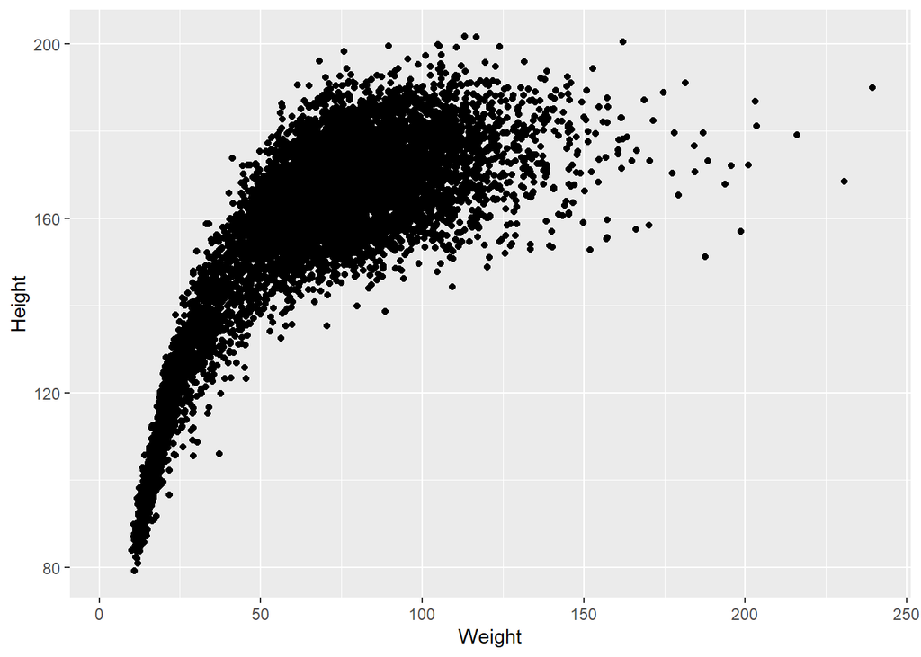

```r
ggplot(health_data, aes(y = Height, x = Weight)) +
    geom_point()
```

Note: you may receive a warning message about missing values being removed. You can ignore that message for the purpose of this workshop.

In the challenge below you can try to create a boxplot. Rather than `geom_point()`, which is used for scatterplots, you will use `geom_boxplot()`.

**Challenge**: Create a boxplot of `sepal.length` across `variety` from the `flower_data`. Think closely about which variables should be denoted as `y` and `x` as the mappings inside `aes()`. Find the solution in the drop-down.**

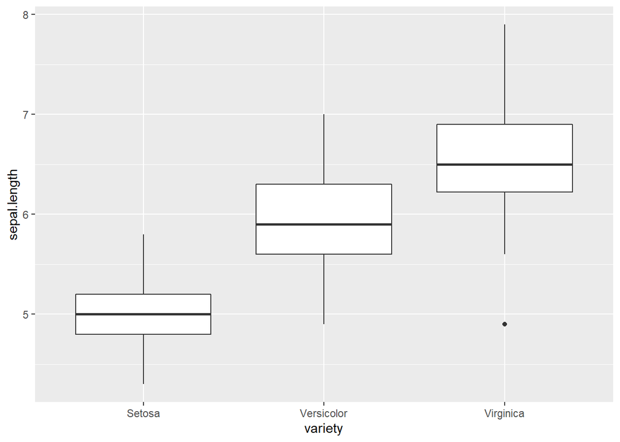

```r
ggplot(flower_data, aes(y = sepal.length, x = variety)) +
    geom_boxplot()
```

## 6.3 Adding additional elements to a plot

`ggplot2` offers a lot more beyond selecting variables in the `<MAPPING>` and selecting a plot type through the `<GEOM_FUNCTION()>`. Often the best way to learn how to perform a specific operation with `ggplot2` is to consult Google. In this section we will show this through the addition of a title to our plot.

Let’s try to add a title to our plot of `Height` vs. `Weight`. Since we have not learned how to do this, we will consult Google. Searching efficiently is a skill which you will develop as you use RStudio. We may for example search “ggplot r add title”. The following pages are included in the result, which all look like tutorials:

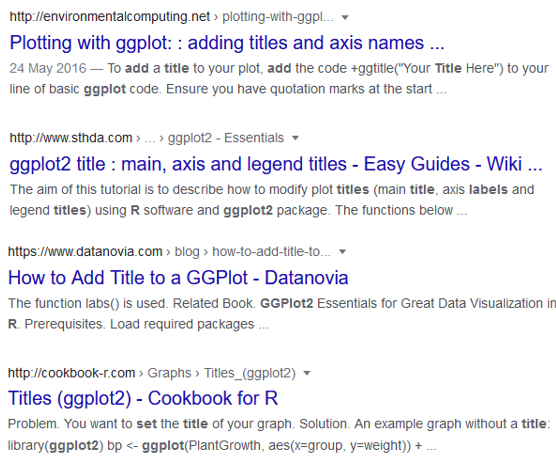

*Searching on Google often reveals tutorials*.

Following the tutorial on “sthda.com”, which is a common source for R tutorials, brings us to an index which includes a link to information on titles in `ggplot2`:

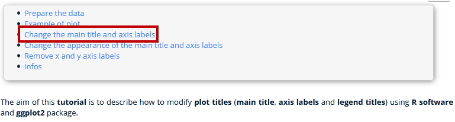

*An indexed tutorial on sthda.com, including a section on titles*.

Following this link shows that the tutorial advises using `+ labs(title = "…")` to add a title:

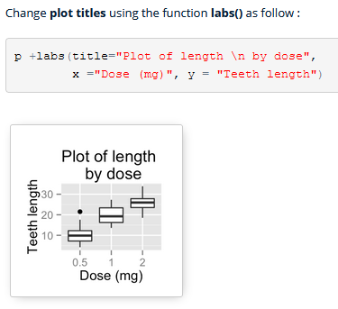

*The section on titles on sthda.com*.

Trying this with our plot gives:

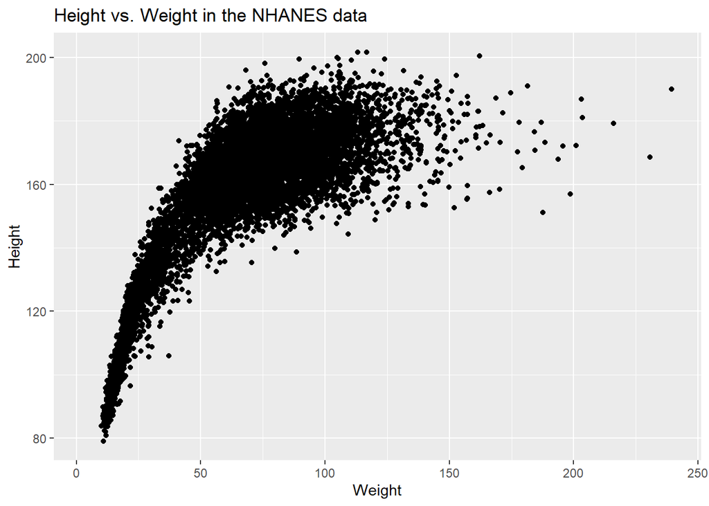

```r
ggplot(health_data, aes(y = Height, x = Weight)) +
  geom_point() +
  labs(title = "Height vs. Weight in the NHANES data")
```

## 6.4 Exporting plots using `ggsave()`

If you are writing a report or manuscript outside of RStudio, you will likely need to export figures. This can be done using `ggsave()`. Three things to note about this function are:

- By default, `ggsave()` saves the last plot created.
- `ggsave()` requires a file name, such as `"height_weight_plot.png"`. The plot is saved under this filename in the specified directory.
- `ggsave()` uses the file extension given in the file name. For example, `"height_weight_plot.png"` will produce a `.png` file, while `"height_weight_plot.pdf"` will produce a `.pdf` file.

For example, to save our `Height` vs `Weight` plot as a `.png` file, we run:

```r
ggplot(health_data, aes(y = Height, x = Weight)) +
  geom_point() +
  labs(title = "Height vs. Weight in the NHANES data")
```

```r
ggsave("results/height_weight_plot.png")
```

We should then have the file `"height_weight_plot.png"` in our `results` directory.

**Challenge**: Boxplots are often being replaced by violin plots, as these show the distribution of the data more clearly. Use Google to find the command for a violin plot. Then, adapt your code for the boxplot of `sepal.length` across `variety` from the `flower_data` to create a violin plot. Finally, save this plot as a `.pdf` file. Find the solution in the drop-down.**

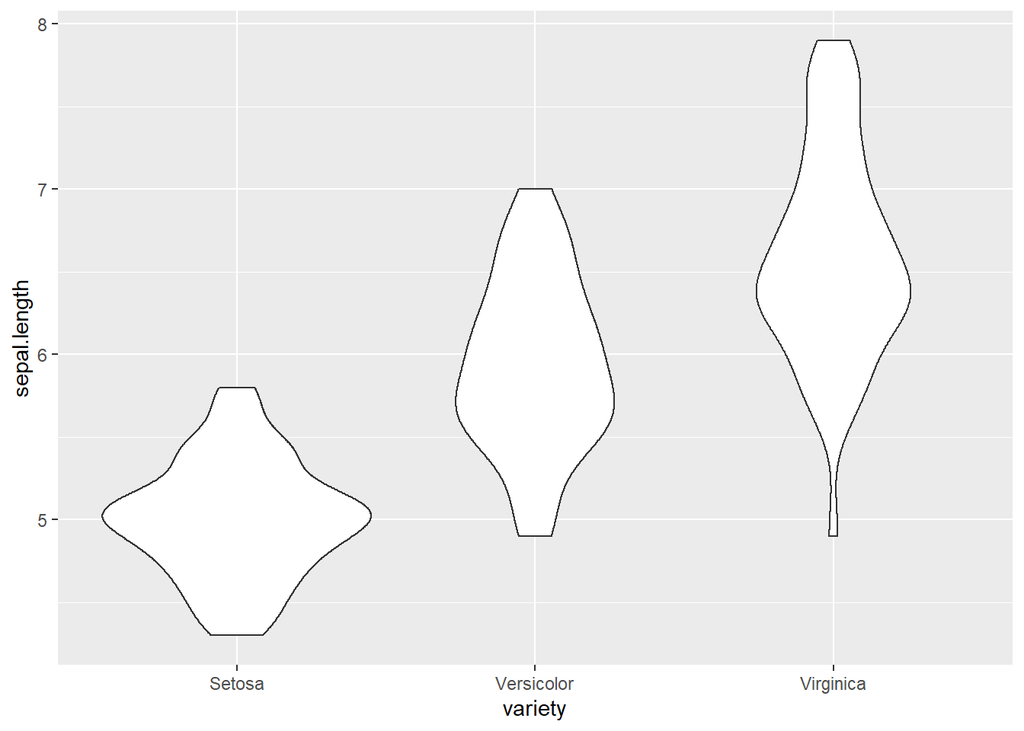

```r
ggplot(flower_data, aes(y = sepal.length, x = variety)) +
    geom_violin()
```

```r
# To export to pdf, we use the .pdf file extension
ggsave("results/sepal_length_by_variety_violin_plot.pdf")
```

```r
# To export to pdf, we use the .pdf file extension
ggsave("../results/sepal_length_by_variety_violin_plot.pdf")
```

# 7 Data analysis in R

In order to follow this section, install the libraries `ggpubr`, `rstatix` and `corrr`:

```r
install.packages("ggpubr")
install.packages("rstatix")
install.packages("corrr")
```

And now load them:

```r
# loading the packages
library(ggpubr)
library(rstatix)
library(corrr)
```

> Questions:  
> 1. What is the general format of a t-test in R?  
> 2. What is the general format of a correlation in R?  
> 3. How to test the assumptions of the t-test and correlations in R?  
> 4. How to use `ggplot2` to aid model interpretation?

> Objectives:  
> 1. Describe the core components of a t-test and correlation;  
> 2. Create boxplots and qqplots to test the assumptions of the statistical models; 3. Adjust `ggplot2` objects.

Additionally to being able to do data wrangling and plotting, you may also want to run some statistical analysis. Here we aim to give an example of some of the tests that you may be interested in running.

## 7.1 Independent t-test

In the case of the `flower_data` that we have been working with, we may be interested in determining whether `sepal.length` differs between the `Setosa` and `Versicolor` varieties. This will entail a few steps:

1. First, we may be interested in getting some summary statistics before any statistical testing. Here we use `get_summary_stats()` rather than `summarise()` as we did earlier in the workshop.

```r
flower_data %>% group_by(variety) %>%
  get_summary_stats(sepal.length, type = "mean_sd")
```

```
## # A tibble: 3 x 5
##   variety    variable         n  mean    sd
##   <chr>      <chr>        <dbl> <dbl> <dbl>
## 1 Setosa     sepal.length    50  5.01 0.352
## 2 Versicolor sepal.length    50  5.94 0.516
## 3 Virginica  sepal.length    50  6.59 0.636
```

## 7.2 Assumptions of t-test

The two-samples independent t-test assume the following characteristics about the data:

### 7.2.1 **Independence of the observations**. Each subject should belong to only one group. There is no relationship between the observations in each group;

The assumption of independence is met since the categories are mutually exclusive, each flower belongs to only one variety.

### 7.2.2 **No significant outliers** in the two groups;

Use `filter()` to select rows from `variety` that match our criteria, i.e. only the rows related to `Setosa` and `Versicolor` varieties;

```r
setosa_versicolor_data <- flower_data %>%
  filter(variety != "Virginica")
```

Create a boxplot using the `ggplot()` function previous introduced.

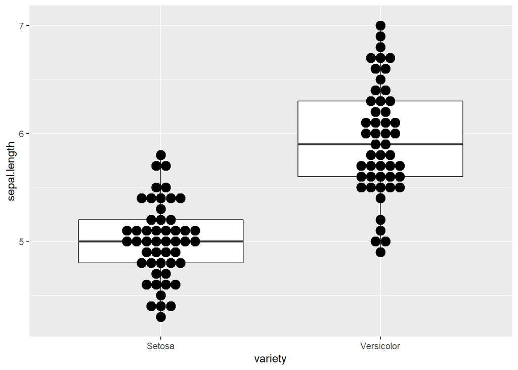

```r
bxp <- ggplot(setosa_versicolor_data, aes(x=variety, y=sepal.length)) +
  geom_boxplot()+
  geom_dotplot(binaxis='y', stackdir='center',
                 position=position_dodge(1))

bxp
```

The boxplot shows no clear evidence of outliers, yet if you are new to visual inspection and want to check if your impression is correct, you can follow-up by using the function `identify_outliers()` from the `rstatix` package.

```r
flower_data %>%
  group_by(variety) %>%
  identify_outliers(sepal.length)
```

```
## # A tibble: 1 x 7
##   variety   sepal.length sepal.width petal.length petal.width is.outlier
##   <chr>            <dbl>       <dbl>        <dbl>       <dbl> <lgl>
## 1 Virginica          4.9         2.5          4.5         1.7 TRUE
## # ... with 1 more variable: is.extreme <lgl>
```

There were no extreme outliers.

### 7.2.3 **Normality:** the data for each group should be approximately normally distributed;

There are multiple ways of checking for normality. Here we will focus on two methods: Shapiro-Wilk test and qqplots. The important thing to know about qqplots is that they compare the data (on the y-axis) against a theoretical distribution (on the x-axis). If the points fall on the identity line, then the data is close to the theoretical distribution. Qqplots are advantageous in relation to tests of normality as these tend to be highly sensitive to small deviations from normality in large sample sizes, so always visually inspect your data.

To create a qqplot of `sepal.length` for each `variety` in our `setosa_versicolor_data`, we:

1. Use the `ggqqplot()` function from the `ggpubr` library;
2. Include `setosa_versicolor_data` as our `<DATA>`;
3. Specify the mappings `x = "sepal.length"` and facet.by = “`variety"`;

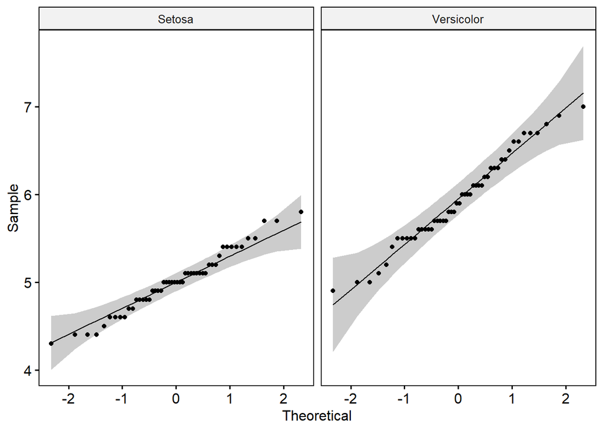

```r
ggqqplot(setosa_versicolor_data, x = "sepal.length", facet.by = "variety")
```

The qqplots reveal no significant deviations from normality.

We can further confirm the normality of our distribution by running a test of normality using the `shapiro_test`from the`rstatix` library.

If the data is normally distributed, or approximates a normal distribution, the Shapiro-Wilk test should be greater than .05.

```r
setosa_versicolor_data %>%
  group_by(variety) %>%
  shapiro_test(sepal.length)
```

```
## # A tibble: 2 x 4
##   variety    variable     statistic     p
##   <chr>      <chr>            <dbl> <dbl>
## 1 Setosa     sepal.length     0.978 0.460
## 2 Versicolor sepal.length     0.978 0.465
```

Since the p-values are greater than .05 for both groups, there is no indication that the data is not normally distributed.

### 7.2.4 **Homogeneity of variances**: the variance of the outcome variable should be similar in each group;

Similarly to the `shapiro_test`, we can test whether both groups show similar variance by using the `levene_test` function from `rstatix` library.

The Levene’s test should be non-significant (greater than .05) if the variances of both groups are similar.

```r
setosa_versicolor_data %>%
  levene_test(sepal.length~variety)
```

```
## # A tibble: 1 x 4
##     df1   df2 statistic       p
##   <int> <int>     <dbl>   <dbl>
## 1     1    98      8.17 0.00520
```

The p-value of the Levene’s test is significant, suggesting that there is a significant difference between the variances of the two groups. Therefore, we’ll use the `Weltch t-test,` which doesn’t assume the equality of the two variances.

## 7.3 Fitting an independent t-test()

Since the data meets the assumptions of independence, normality and does not show extreme outliers we will proceed to run an independent t-test. First, we will fit the independent t-test with the `t_test()`command. Within the command, the model is denoted by `formula = outcome variable ~ explanatory variable`. Second, since the assumption of homogeneity of variance was not met, we will need to set `var.equal` to false. Final, given that we are running an independent t-test, we need to set `paired` to false.

```r
t.test <- setosa_versicolor_data %>%
  t_test(sepal.length ~ variety, var.equal = FALSE, paired = FALSE)

t.test
```

```
## # A tibble: 1 x 8
##   .y.          group1 group2        n1    n2 statistic    df        p
## * <chr>        <chr>  <chr>      <int> <int>     <dbl> <dbl>    <dbl>
## 1 sepal.length Setosa Versicolor    50    50     -10.5  86.5 3.75e-17
```

### 7.3.1 Report

Overall, there appears to be a significant difference between `setosa` and `versicolor` varieties for `sepal.length`, with the `versicolor` variety showing a statistically significant higher `sepal.length` than the `setosa variety`, *t*(86.54) = -10.52, *p* < .001.

## 7.4 One-sample t-test

If we wanted to extend the model we just fitted to one-sample t-test to check whether the petal length for the Versicolor variety is different than a certain value, we would first have to subset our data. And then proceed to fit the model as we have already established that the assumptions for a one-sample t-test are met. One-sample t-tests are fitted using the same command as before `t_test`, yet the formula is denoted by `outcome variable ~ 1, mu = parameter.`

In this example we want to check whether the petal length of the Versicolor variety is significantly different from 3 cm.

```r
Versicolor <- flower_data %>%
  filter(variety == "Versicolor")

Versicolor %>%
  t_test(petal.length ~ 1, mu = 3)
```

```
## # A tibble: 1 x 7
##   .y.          group1 group2         n statistic    df        p
## * <chr>        <chr>  <chr>      <int>     <dbl> <dbl>    <dbl>
## 1 petal.length 1      null model    50      19.0    49 3.29e-24
```

**Challenge**: Now that we have established that the samples are normality distributed and do not show outliers, check whether the `petal.length` of `Iris Setosa` are statistically different from 5 cm.**

```r
setosa <- flower_data %>%
  filter(variety == "Setosa")

setosa %>%
  t_test(petal.length ~ 1, mu = 5)
```

## 7.5 Pearson’s correlation

We may be additionally interested in determining whether there is a correlation between `sepal.length` and `sepal.width` for the `Virginica` variety using the `correlate()` function from the `corrr` package.

First we need to filter the data.

```r
virginica <- flower_data %>%
      filter(variety == "Virginica")
```

Then we need to inspect whether there is a linear relationship between `sepal.length` and `sepal.width.`

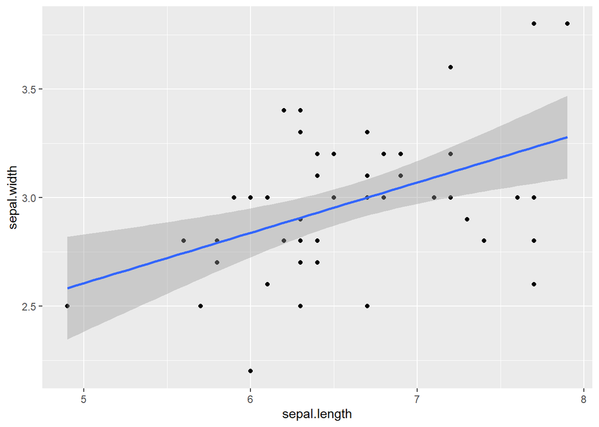

```r
ggplot(virginica, aes(x=sepal.length, y=sepal.width)) +
      geom_point()+
      geom_smooth(method=lm)
```

Finally, given that the relationship appears to be linear, we can now compute a Pearson’s correlation with the `correlate()` command from the `corrr` library. Within the command, you need to assign the variables of interest to x and y, the order does not matter.

```r
correlate(x = virginica$sepal.length, y = virginica$sepal.width)
```

```
##
## Correlation method: 'pearson'
## Missing treated using: 'pairwise.complete.obs'
```

```
## # A tibble: 1 x 2
##   term      x
##   <chr> <dbl>
## 1 x     0.457
```

```r
#or if you wished to run the correlations between all variables in the dataset you could simply do the following:

virginica %>% dplyr::select_if(is.numeric) %>% correlate(use = "pairwise.complete.obs", method = "pearson")
```

```
##
## Correlation method: 'pearson'
## Missing treated using: 'pairwise.complete.obs'
```

```
## # A tibble: 4 x 5
##   term         sepal.length sepal.width petal.length petal.width
##   <chr>               <dbl>       <dbl>        <dbl>       <dbl>
## 1 sepal.length       NA           0.457        0.864       0.281
## 2 sepal.width         0.457      NA            0.401       0.538
## 3 petal.length        0.864       0.401       NA           0.322
## 4 petal.width         0.281       0.538        0.322      NA
```

```r
# dplyr::select_if(is.numeric) is used to only select numerical columns
```

### 7.5.1 Report

```r
# subset dataset for Virginica

correlate(health_data$Age, health_data$Weight)

ggplot(health_data, aes(x=Height, y=Weight)) + geom_point()
```

# 8 Optional material

> Questions:  
> 1. How are string variables converted to factor variables?  
> 2. How are groups along the x-axis reordered in a ggplot graph?  
> 3. How are multiple ggplot graphs grouped into one plotting region?

> Objectives:  
> 1. Use `as_factor()` to convert a character variable to a factor variable.  
> 2. Use `fct_relevel()` to reorder groups along the x-axis of a ggplot graph.  
> 3. Use the `patchwork` package to group multiple `ggplot()` graphs together.

## 8.1 Using `as_factor()` for categorical variables

When we import categorical variables as part of a *tibble*, they appear as a `character` column. See for example the `Sex` column in health_data:

```r
head(health_data)
```

```
## # A tibble: 6 x 5
##      ID Sex      Age Height Weight
##   <dbl> <chr>  <dbl>  <dbl>  <dbl>
## 1 71892 male       0    NA     7.7
## 2 71460 female    47   148.   62.3
## 3 58929 male      78   178.   63.4
## 4 64041 male       9   151.   62.9
## 5 69722 male       7   116.   21.4
## 6 59289 male      30   165.   50.1
```

A `character` column in RStudio is a column with words (also known as “strings”). For downstream analyses, it is often useful to convert a categorical `character` column into a `factor` column. This has the following advantages:

- A character column is prone to typos which can go unseen. In a factor column, there is a limited set of categories (known as levels), such that typos can be spotted easily.
- A character column does not specify an order for the categories, which can complicate downstream analyses. In a factor column, the levels can be ordered in a specific way, such that plots and models treat the column as we would like them to (e.g. plot the 12 months of the year in the correct order, rather than alphabetically).

We can convert a character column into a factor using the `as_factor()` function from the `forcats` package. We do this inside `mutate()`. Ensure that you have the `forcats` package installed before you run the code below.

```r
library(forcats) # load the required package

health_data_factor <- health_data %>%
  mutate(Sex = as_factor(Sex))
```

Using `head()`, we can see that `Sex` has become a factor. See the `<fct>` under `Sex`:

```r
head(health_data_factor)
```

```
## # A tibble: 6 x 5
##      ID Sex      Age Height Weight
##   <dbl> <fct>  <dbl>  <dbl>  <dbl>
## 1 71892 male       0    NA     7.7
## 2 71460 female    47   148.   62.3
## 3 58929 male      78   178.   63.4
## 4 64041 male       9   151.   62.9
## 5 69722 male       7   116.   21.4
## 6 59289 male      30   165.   50.1
```

We can check that our variable is free of typos by checking the levels (i.e. categories) inside our variable using the `pull()` and `levels()` *functions*:

```r
health_data_factor %>%
  pull(Sex) %>%
  levels()
```

```
## [1] "male"   "female"
```

This shows us that our factor variable is free of typos, since we have only two levels with spelling as expected.

## 8.2 Using `fct_relevel()` to reorder groups in a factor variable

We can change the order of the levels using `fct_relevel()` inside `mutate()`:

```r
health_data_factor_relevel <- health_data_factor %>%
  mutate(Sex = fct_relevel(Sex, "female", "male"))
```

We then see that the levels have been reordered:

```r
health_data_factor_relevel %>%
  pull(Sex) %>%
  levels()
```

```
## [1] "female" "male"
```

Reordering factor levels is handy when you need to rearrange your graphs of data. For example, a boxplot of Height by Sex using `health_data_factor` has “male” as the left-most boxplot:

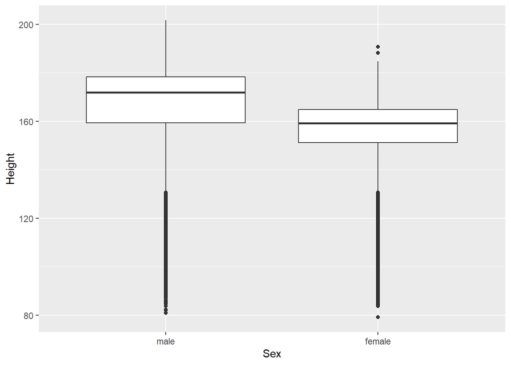

```r
ggplot(health_data_factor, aes(y = Height, x = Sex)) +
    geom_boxplot()
```

In contrast, the same code on `health_data_factor_relevel` returns a graph with “female” as the left-most boxplot:

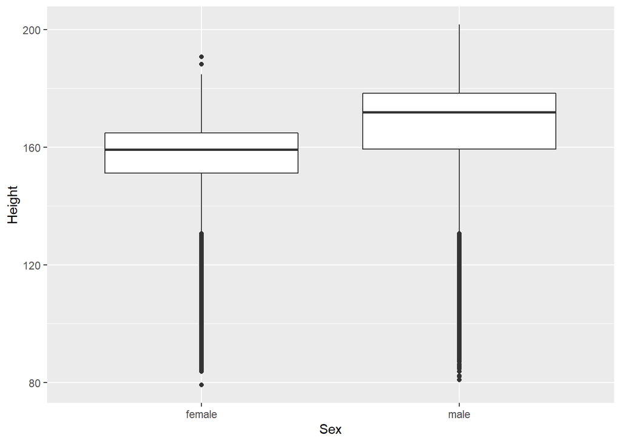

```r
ggplot(health_data_factor_relevel, aes(y = Height, x = Sex)) +
    geom_boxplot()
```

**Challenge**: Create an object named `flower_data_factor`, with the `variety` column as a factor. Ensure that the levels are ordered as “Versicolor”, “Virginica”, “Setosa”. Find the solution in the drop-down.**

```r
flower_data_factor <- flower_data %>%
  mutate(variety = as_factor(variety)) %>%
  mutate(variety = fct_relevel(variety,
                               "Versicolor", "Virginica", "Setosa"))

#check that reordering the factor levels worked
flower_data_factor %>%
  pull(variety) %>%
  levels()
```

```
## [1] "Versicolor" "Virginica"  "Setosa"
```

## 8.3 Grouping multiple plots into one region using the `patchwork` package

Often we want to visualise data in more than one way. In this case, it is useful to be able to arrange multiple plots into one plotting region, such that RStudio returns one image which contains all our plots. We can do so using the `patchwork` package. Before you proceed, ensure that this package is installed and loaded.

To use `patchwork`, we need to save each of our plots as an object. For example, to save our `Height` vs `Weight` plot under the name `p1`, we run:

```r
p1 <- ggplot(health_data, aes(y = Height, x = Weight)) +
  geom_point()
```

Let’s save a second plot under the name `p2`, this time a scatterplot of `Height` across `Age`:

```r
p2 <- ggplot(health_data, aes(y = Height, x = Age)) +
  geom_point()
```

Both plots can be shown in one plotting region by running the object names, separated by a `+`:

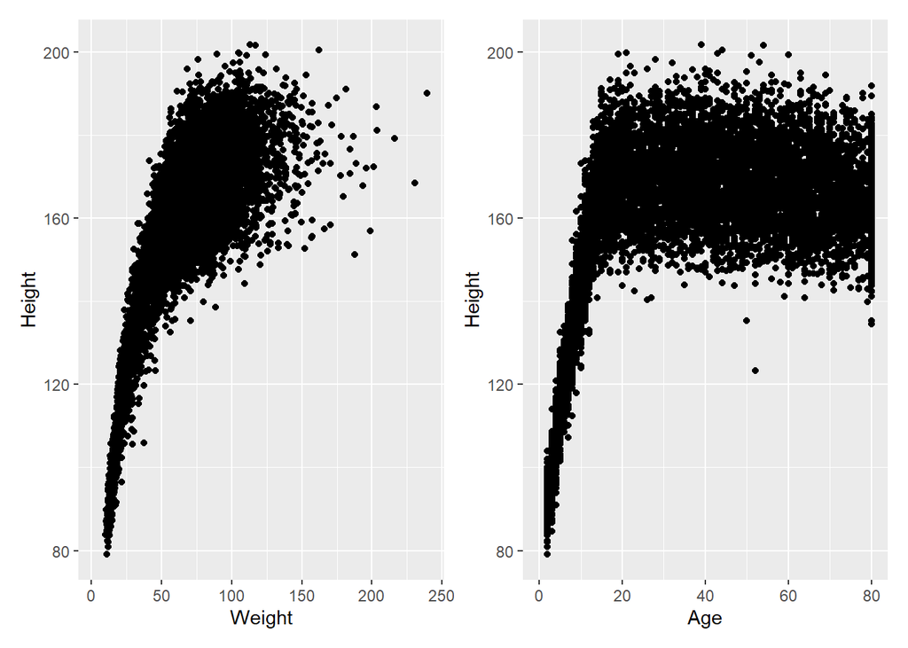

```r
p1 + p2
```

**Challenge**: Save the boxplot and the violin plot of `sepal.length` as objects, named `p1` and `p2`. Plot these graphs in one plotting region using `patchwork`. Then, save this as a `.pdf` file in your results folder. Find the solution in the drop-down.**

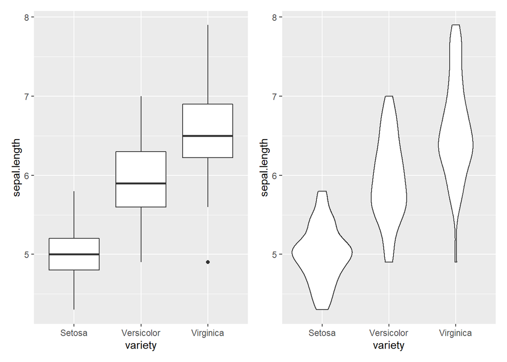

```r
p1 <- ggplot(flower_data, aes(y = sepal.length, x = variety)) +
  geom_boxplot()

p2 <- ggplot(flower_data, aes(y = sepal.length, x = variety)) +
  geom_violin()

p1 + p2
```

```r
ggsave("results/sepal_length_plots.pdf")
```

```r
ggsave("../results/sepal_length_plots.pdf")
```